# Análisis evolución Covid-19 para regiones de Chile (26/03/2020)

Claudio Bustos

26/3/2020

**NOTA**: Lo que presento aquí es un ejemplo de como realizar análisis de series de tiempo, usando datos de la evolución total de casos disponible en fuentes públicas en internet. No tiene ninguna validez epidemiológica, ya que eso requería un modelo de la diseminación de la enfermedad. En particular, las predicciones son solo válidas en cuanto no existan cambios en las políticas públicas; si los hay, se esperaría que (ojalá) las predicciones fuesen incorrectas.

- Reportes anteriores: https://github.com/clbustos/analisis_covid19_chile

## Análisis de datos observados

El día de hoy se incorpora Antofagasta, con una progresión de casos pequeña. Araucanía destaca por su alza sin un claro efecto de las medidas de mitigación, en tanto que Biobío sigue estando muy cerca de la Región de Metropolitana. La situación en Ñuble aparece ya contenida.

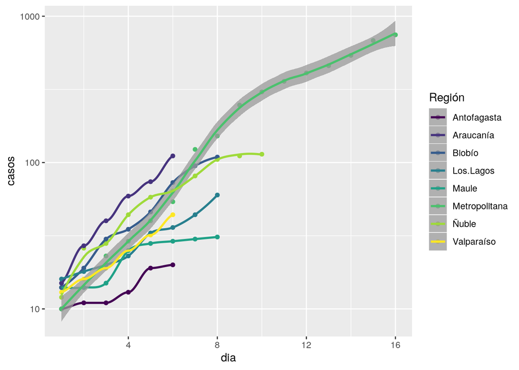

El mismo gráfico, pero separando las regiones

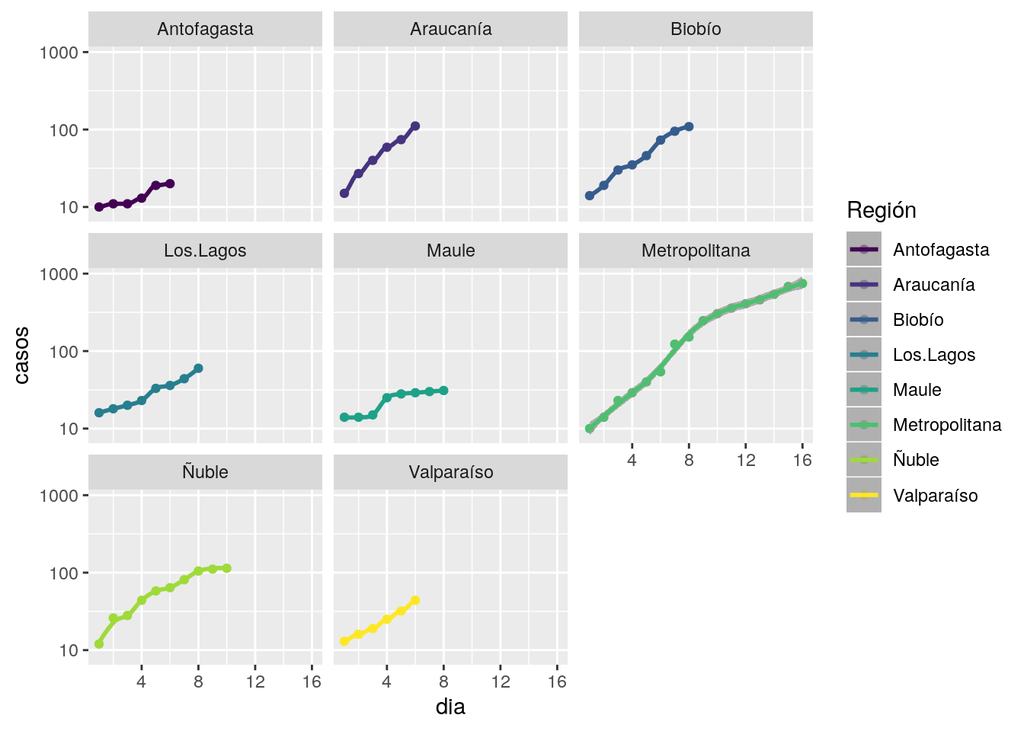

El día de hoy podemos distinguir tres tipos de regiones, de avance rápido (sobre 30% diario), avance moderado (20%-30%) y lento (<20%)

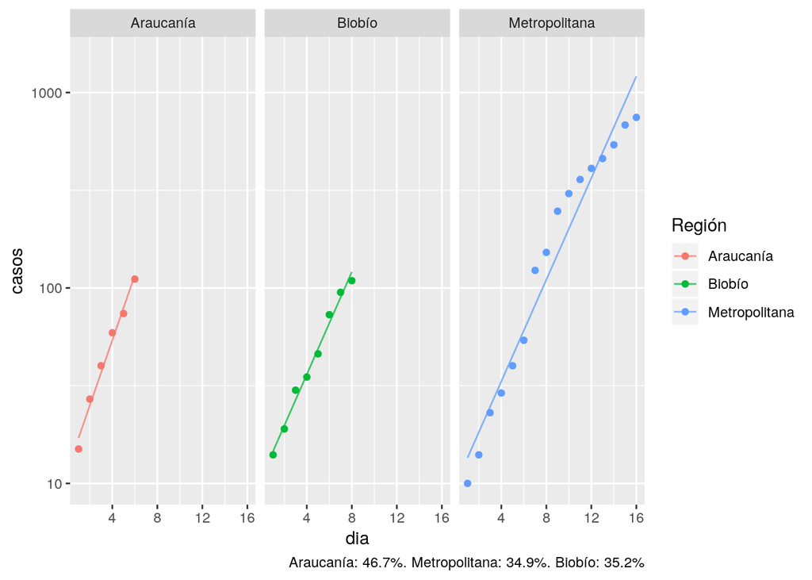

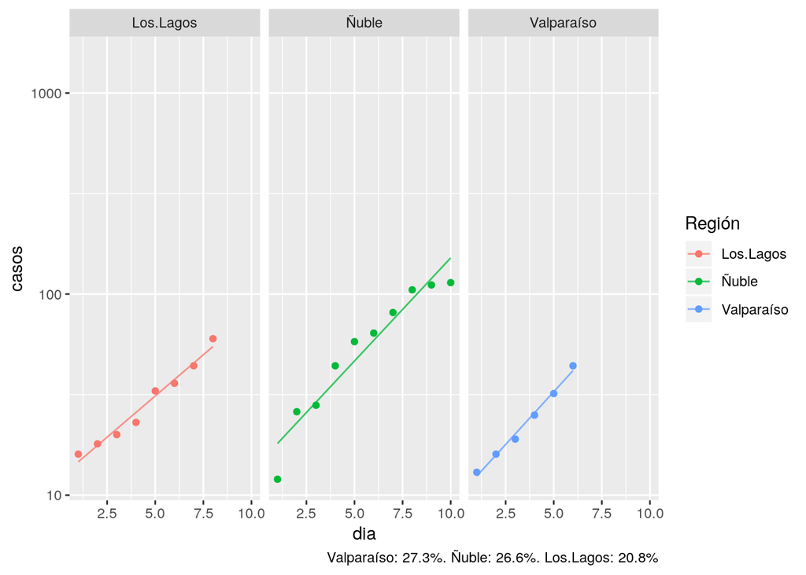

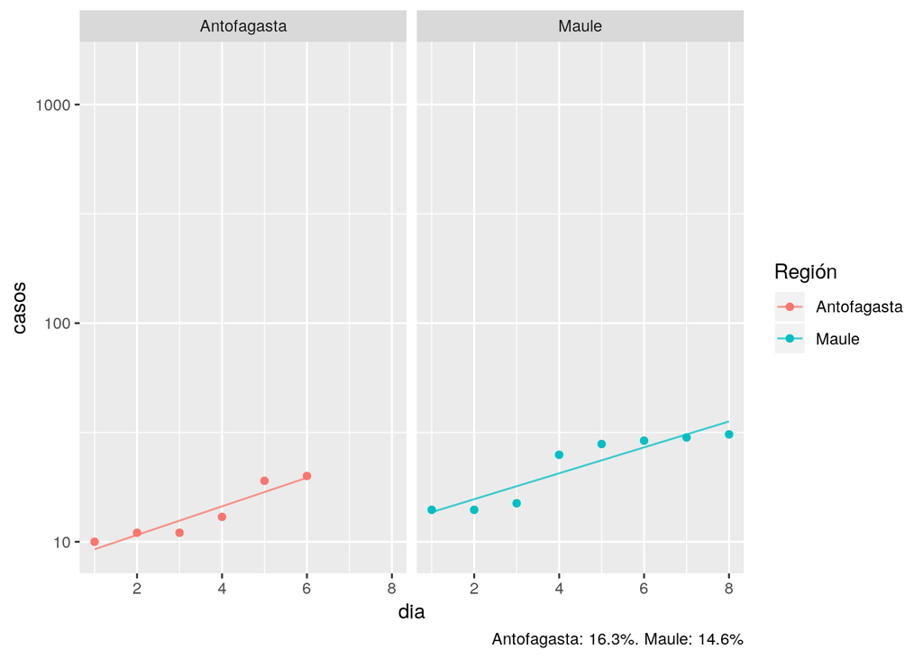

Graficando la tasa de nuevos casos usando media móvil con ventana de 3 días, se aprecia mejor el control que se ha logrado sobre la región Metropolitana, Maule y Ñuble, y se aprecia mejor el problema en Biobío, La Araucanía y Valparaíso.

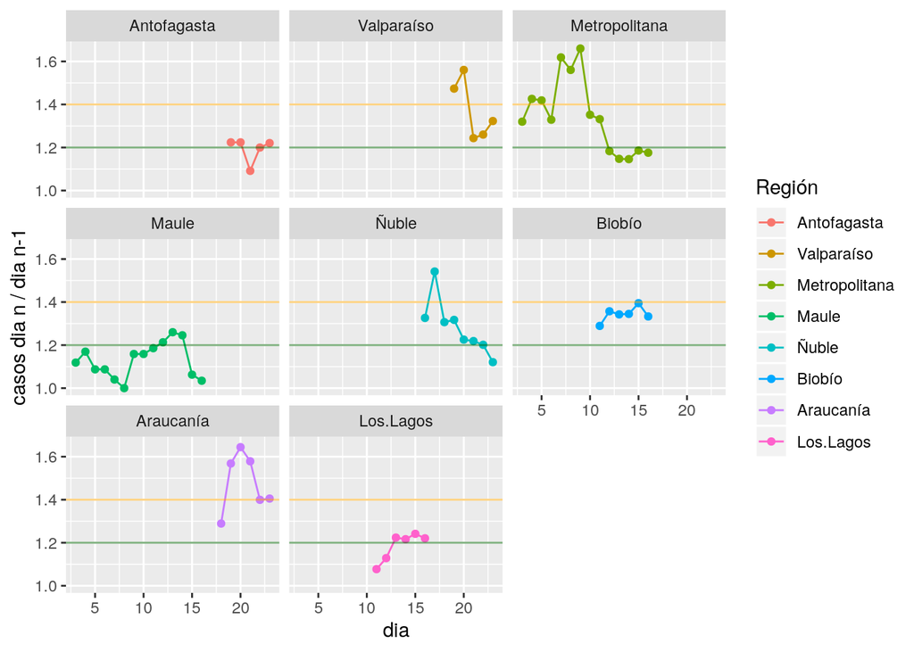

## Predicción

**NOTA**: Se presentan aquí tres metodologías de predicción. Recuerden que corresponden a un ejercicio para mostrar las bondades y dificultades de cada técnica

Para predecir, se ocupan tres técnicas distintas:

- regresión exponencial sobre datos totales: se ajusta la serie a la expresión $y=a * r^t$ usando regresión lineal. Es válida si el proceso no cambia a lo largo del tiempo. Se caracteriza porque el intervalo de confianza es constante al transformar los datos a logaritmo.
- tendencia sobre casos nuevos + AR(1): Se modela la tendencia de los casos nuevos usando regresión exponencial, más la relación que existe entre dos mediciones contiguas. El error estándar aumenta de manera importante a lo largo del tiempo, tanto por el error al calcular la tendencia, como por el componente AR(1). El valor medio obtenido es bastante sensible a los cambios en las mediciones finales.
- ARIMA(1,1,0) más deriva: Se ocupa un modelo autorregresivo, con diferenciación y deriva. Esto implica que se asume que los datos tienen una tendencia constante (como el modelo de regresión exponencial), y pero se modela la relación que existe entre casos contiguos (como el modelo de tendencia). Tiende a generar modelos menos variables que el de tendencia + AR(1), pero asume que la curva de crecimiento es la misma de toda la serie de datos.

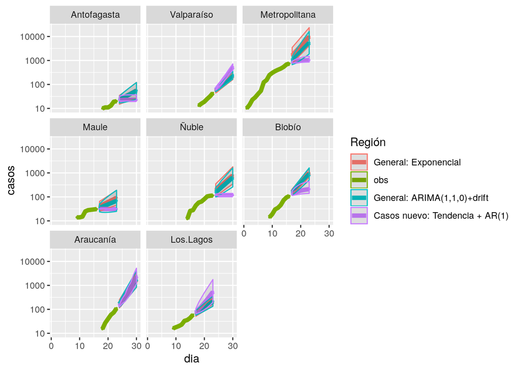

Casos nuevos: tendencia + AR(1) : Antofagasta

|  | dia | casos | li | ls |
| --- | --- | --- | --- | --- |
| **7** | 24 | 22.21 | 20.4 | 32.22 |
| **8** | 25 | 22.49 | 20.43 | 34.65 |
| **9** | 26 | 22.66 | 20.45 | 36.42 |
| **10** | 27 | 22.67 | 20.45 | 36.61 |
| **11** | 28 | 22.68 | 20.45 | 36.65 |
| **12** | 29 | 22.68 | 20.45 | 36.65 |
| **13** | 30 | 22.68 | 20.45 | 36.65 |

Casos nuevos: tendencia + AR(1) : Valparaíso

|  | dia | casos | li | ls |
| --- | --- | --- | --- | --- |
| **7** | 24 | 59.32 | 57.18 | 61.81 |
| **8** | 25 | 85.1 | 78.08 | 93.61 |
| **9** | 26 | 118.4 | 104 | 136.6 |
| **10** | 27 | 174.4 | 145.9 | 211.2 |
| **11** | 28 | 247.6 | 199.1 | 311.8 |
| **12** | 29 | 370.1 | 286.1 | 484.6 |
| **13** | 30 | 532.4 | 398.6 | 718.6 |

Casos nuevos: tendencia + AR(1) : Metropolitana

|  | dia | casos | li | ls |
| --- | --- | --- | --- | --- |
| **17** | 17 | 816.7 | 773.3 | 929.2 |
| **18** | 18 | 876.2 | 795.9 | 1086 |
| **19** | 19 | 926.4 | 815 | 1218 |
| **20** | 20 | 966.6 | 830.2 | 1324 |
| **21** | 21 | 997.6 | 842 | 1405 |
| **22** | 22 | 1021 | 850.7 | 1466 |
| **23** | 23 | 1037 | 856.9 | 1509 |

Casos nuevos: tendencia + AR(1) : Maule

|  | dia | casos | li | ls |
| --- | --- | --- | --- | --- |
| **9** | 17 | 31.17 | 31.02 | 32.17 |
| **10** | 18 | 31.21 | 31.03 | 32.51 |
| **11** | 19 | 31.22 | 31.03 | 32.57 |
| **12** | 20 | 31.22 | 31.03 | 32.58 |
| **13** | 21 | 31.22 | 31.03 | 32.58 |
| **14** | 22 | 31.22 | 31.03 | 32.58 |
| **15** | 23 | 31.22 | 31.03 | 32.58 |

Casos nuevos: tendencia + AR(1) : Ñuble

|  | dia | casos | li | ls |
| --- | --- | --- | --- | --- |
| **11** | 24 | 117 | 114.6 | 128.9 |
| **12** | 25 | 117.9 | 114.7 | 134.9 |
| **13** | 26 | 118.3 | 114.8 | 138.1 |
| **14** | 27 | 118.4 | 114.8 | 139.1 |
| **15** | 28 | 118.5 | 114.8 | 139.4 |
| **16** | 29 | 118.5 | 114.8 | 139.4 |
| **17** | 30 | 118.5 | 114.8 | 139.4 |

Casos nuevos: tendencia + AR(1) : Biobío

|  | dia | casos | li | ls |
| --- | --- | --- | --- | --- |
| **9** | 17 | 130.3 | 115.6 | 177.8 |
| **10** | 18 | 149.3 | 121.4 | 240.3 |
| **11** | 19 | 166.8 | 126.7 | 297.9 |
| **12** | 20 | 181.7 | 131.2 | 347 |
| **13** | 21 | 193.7 | 134.9 | 386.5 |
| **14** | 22 | 202.8 | 137.6 | 416.4 |
| **15** | 23 | 209.3 | 139.6 | 437.9 |

Casos nuevos: tendencia + AR(1) : Araucanía

|  | dia | casos | li | ls |
| --- | --- | --- | --- | --- |
| **7** | 24 | 140 | 130.3 | 154.6 |
| **8** | 25 | 215.6 | 174 | 285.4 |
| **9** | 26 | 290.5 | 213.4 | 427.4 |
| **10** | 27 | 490.3 | 311.9 | 833.1 |
| **11** | 28 | 734.9 | 426.4 | 1355 |
| **12** | 29 | 1417 | 733.6 | 2868 |
| **13** | 30 | 2432 | 1177 | 5191 |

Casos nuevos: tendencia + AR(1) : Los.Lagos

|  | dia | casos | li | ls |
| --- | --- | --- | --- | --- |
| **9** | 17 | 74.91 | 64.83 | 106 |
| **10** | 18 | 100.7 | 72.32 | 194.5 |
| **11** | 19 | 134.9 | 82.07 | 314.6 |
| **12** | 20 | 186.7 | 96.78 | 497.2 |
| **13** | 21 | 261.8 | 118.1 | 762.1 |
| **14** | 22 | 374.5 | 150 | 1160 |
| **15** | 23 | 543.4 | 197.9 | 1755 |

Exponencial : Antofagasta

|  | dia | casos | li | ls |
| --- | --- | --- | --- | --- |
| **7** | 24 | 22.82 | 14.97 | 34.81 |
| **8** | 25 | 26.54 | 16.57 | 42.49 |
| **9** | 26 | 30.85 | 18.24 | 52.18 |
| **10** | 27 | 35.86 | 19.99 | 64.34 |
| **11** | 28 | 41.7 | 21.84 | 79.59 |
| **12** | 29 | 48.47 | 23.82 | 98.67 |
| **13** | 30 | 56.35 | 25.92 | 122.5 |

Exponencial : Valparaíso

|  | dia | casos | li | ls |
| --- | --- | --- | --- | --- |
| **7** | 24 | 52.99 | 43.9 | 63.96 |
| **8** | 25 | 67.46 | 54.69 | 83.22 |
| **9** | 26 | 85.88 | 67.94 | 108.6 |
| **10** | 27 | 109.3 | 84.25 | 141.9 |
| **11** | 28 | 139.2 | 104.3 | 185.7 |
| **12** | 29 | 177.2 | 129.1 | 243.3 |
| **13** | 30 | 225.6 | 159.6 | 319 |

Exponencial : Metropolitana

|  | dia | casos | li | ls |
| --- | --- | --- | --- | --- |
| **17** | 17 | 1635 | 767.6 | 3481 |
| **18** | 18 | 2205 | 1020 | 4770 |
| **19** | 19 | 2976 | 1353 | 6546 |
| **20** | 20 | 4015 | 1793 | 8994 |
| **21** | 21 | 5418 | 2372 | 12374 |
| **22** | 22 | 7310 | 3136 | 17041 |
| **23** | 23 | 9864 | 4141 | 23494 |

Exponencial : Maule

|  | dia | casos | li | ls |
| --- | --- | --- | --- | --- |
| **9** | 17 | 40.72 | 25.47 | 65.1 |
| **10** | 18 | 46.68 | 28.23 | 77.17 |
| **11** | 19 | 53.5 | 31.17 | 91.84 |
| **12** | 20 | 61.33 | 34.3 | 109.7 |
| **13** | 21 | 70.3 | 37.65 | 131.2 |
| **14** | 22 | 80.58 | 41.25 | 157.4 |
| **15** | 23 | 92.37 | 45.11 | 189.1 |

Exponencial : Ñuble

|  | dia | casos | li | ls |
| --- | --- | --- | --- | --- |
| **11** | 24 | 191.7 | 104.5 | 351.8 |
| **12** | 25 | 242.8 | 128.4 | 458.8 |
| **13** | 26 | 307.4 | 157.4 | 600.3 |
| **14** | 27 | 389.3 | 192.4 | 787.7 |
| **15** | 28 | 493 | 234.6 | 1036 |
| **16** | 29 | 624.2 | 285.4 | 1365 |
| **17** | 30 | 790.5 | 346.6 | 1803 |

Exponencial : Biobío

|  | dia | casos | li | ls |
| --- | --- | --- | --- | --- |
| **9** | 17 | 163.4 | 124.7 | 214.2 |
| **10** | 18 | 221 | 165.3 | 295.4 |
| **11** | 19 | 298.9 | 218.8 | 408.2 |
| **12** | 20 | 404.2 | 289 | 565.2 |
| **13** | 21 | 546.6 | 381.2 | 783.7 |
| **14** | 22 | 739.1 | 502.2 | 1088 |
| **15** | 23 | 999.6 | 660.9 | 1512 |

Exponencial : Araucanía

|  | dia | casos | li | ls |
| --- | --- | --- | --- | --- |
| **7** | 24 | 170.6 | 114.6 | 254.1 |
| **8** | 25 | 250.3 | 160.5 | 390.4 |
| **9** | 26 | 367.3 | 223.7 | 603.3 |
| **10** | 27 | 539 | 310.5 | 935.8 |
| **11** | 28 | 790.9 | 429.7 | 1456 |
| **12** | 29 | 1161 | 593.3 | 2270 |
| **13** | 30 | 1703 | 818.1 | 3545 |

Exponencial : Los.Lagos

|  | dia | casos | li | ls |
| --- | --- | --- | --- | --- |
| **9** | 17 | 66.22 | 51.42 | 85.28 |
| **10** | 18 | 79.97 | 60.98 | 104.9 |
| **11** | 19 | 96.57 | 72.17 | 129.2 |
| **12** | 20 | 116.6 | 85.26 | 159.5 |
| **13** | 21 | 140.8 | 100.6 | 197.2 |
| **14** | 22 | 170.1 | 118.5 | 244 |
| **15** | 23 | 205.4 | 139.6 | 302.2 |

ARIMA(1,1,0) con deriva : Antofagasta

|  | dia | casos | li | ls |
| --- | --- | --- | --- | --- |
| **7** | 24 | 23.32 | 16.75 | 32.48 |
| **8** | 25 | 26.84 | 17.31 | 41.61 |
| **9** | 26 | 30.93 | 18.25 | 52.42 |
| **10** | 27 | 35.64 | 19.5 | 65.15 |
| **11** | 28 | 41.08 | 21.01 | 80.3 |
| **12** | 29 | 47.34 | 22.78 | 98.36 |
| **13** | 30 | 54.55 | 24.81 | 119.9 |

ARIMA(1,1,0) con deriva : Valparaíso

|  | dia | casos | li | ls |
| --- | --- | --- | --- | --- |
| **7** | 24 | 56.55 | 49.72 | 64.31 |
| **8** | 25 | 72.25 | 59.75 | 87.36 |
| **9** | 26 | 92.27 | 72.85 | 116.9 |
| **10** | 27 | 117.8 | 89.5 | 155.1 |
| **11** | 28 | 150.5 | 110.5 | 204.9 |
| **12** | 29 | 192.2 | 136.8 | 269.8 |
| **13** | 30 | 245.4 | 169.9 | 354.4 |

ARIMA(1,1,0) con deriva : Metropolitana

|  | dia | casos | li | ls |
| --- | --- | --- | --- | --- |
| **17** | 17 | 983.5 | 666.1 | 1452 |
| **18** | 18 | 1310 | 743.5 | 2307 |
| **19** | 19 | 1745 | 866.4 | 3513 |
| **20** | 20 | 2324 | 1032 | 5236 |
| **21** | 21 | 3097 | 1246 | 7698 |
| **22** | 22 | 4126 | 1519 | 11208 |
| **23** | 23 | 5497 | 1865 | 16200 |

ARIMA(1,1,0) con deriva : Maule

|  | dia | casos | li | ls |
| --- | --- | --- | --- | --- |
| **9** | 17 | 34.73 | 23.66 | 50.98 |
| **10** | 18 | 38.91 | 22.61 | 66.95 |
| **11** | 19 | 43.58 | 22.42 | 84.72 |
| **12** | 20 | 48.83 | 22.66 | 105.2 |
| **13** | 21 | 54.7 | 23.19 | 129 |
| **14** | 22 | 61.28 | 23.94 | 156.9 |
| **15** | 23 | 68.65 | 24.87 | 189.5 |

ARIMA(1,1,0) con deriva : Ñuble

|  | dia | casos | li | ls |
| --- | --- | --- | --- | --- |
| **11** | 24 | 159.6 | 99.46 | 256 |
| **12** | 25 | 193.8 | 113.2 | 331.7 |
| **13** | 26 | 251.2 | 131.9 | 478.4 |
| **14** | 27 | 315.9 | 154.6 | 645.8 |
| **15** | 28 | 402.9 | 183.3 | 885.7 |
| **16** | 29 | 510.7 | 218.2 | 1195 |
| **17** | 30 | 649 | 261.1 | 1613 |

ARIMA(1,1,0) con deriva : Biobío

|  | dia | casos | li | ls |
| --- | --- | --- | --- | --- |
| **9** | 17 | 152.8 | 116.8 | 199.8 |
| **10** | 18 | 203.7 | 145.6 | 284.9 |
| **11** | 19 | 274.9 | 184.2 | 410.3 |
| **12** | 20 | 369.9 | 234.9 | 582.5 |
| **13** | 21 | 498.2 | 301.5 | 823.4 |
| **14** | 22 | 670.8 | 388.4 | 1159 |
| **15** | 23 | 903.3 | 502.2 | 1625 |

ARIMA(1,1,0) con deriva : Araucanía

|  | dia | casos | li | ls |
| --- | --- | --- | --- | --- |
| **7** | 24 | 165.6 | 124 | 221.3 |
| **8** | 25 | 247.1 | 164.2 | 371.9 |
| **9** | 26 | 368.7 | 223.5 | 608.1 |
| **10** | 27 | 550.1 | 308.7 | 980.2 |
| **11** | 28 | 820.7 | 430.3 | 1565 |
| **12** | 29 | 1225 | 603.7 | 2484 |
| **13** | 30 | 1827 | 851.1 | 3922 |

ARIMA(1,1,0) con deriva : Los.Lagos

|  | dia | casos | li | ls |
| --- | --- | --- | --- | --- |
| **9** | 17 | 70.02 | 56.06 | 87.47 |
| **10** | 18 | 85.18 | 64.64 | 112.2 |
| **11** | 19 | 102.5 | 73.76 | 142.4 |
| **12** | 20 | 123.7 | 85.2 | 179.4 |
| **13** | 21 | 149.1 | 98.75 | 225.1 |
| **14** | 22 | 179.8 | 114.9 | 281.3 |
| **15** | 23 | 216.8 | 134 | 350.7 |

**Fuentes de información**: Principalmente, se utilizó el reporte diario del [MINSAL](https://www.minsal.cl/nuevo-coronavirus-2019-ncov/casos-confirmados-en-chile-covid-19/), usando [Wayback machine](https://archive.org/web/) para recopilar la información ya no disponible.